# Summarize and Explore the Data

Dayanand, Kiran, Ravi

2018-05-21

## Intro

The document introduces the **SmartEDA** package and how it can help you to build exploratory data analysis.

**SmartEDA** includes multiple custom functions to perform initial exploratory analysis on any input data describing the structure and the relationships present in the data. The generated output can be obtained in both summary and graphical form. The graphical form or charts can also be exported as reports.

```
सर्वस्य लोचनं शास्त्रं
Science is the only eye

अनेकसंशयोच्छेदि, परोक्षार्थस्य दर्शक|
सर्वस्य लोचनं शास्त्रं, यस्य नास्त्यन्ध एव सः ||

It blasts many doubts, foresees what is not obvious |
Science is the eye of everyone, one who hasn't got it, is like a blind ||
```

**SmartEDA** package helps you to construct a good base of data understanding. The capabilities and functionalities are listed below

1. **SmartEDA** package will make you capable of applying different types of EDA without having to
   - remember the different R package names
   - write lengthy R scripts
   - manual effort to prepare the EDA report
2. No need to categorize the variables into Character, Numeric, Factor etc. SmartEDA functions automatically categorize all the features into the right data type (Character, Numeric, Factor etc.) based on the input data.
3. ggplot2 functions are used for graphical presentation of data
4. Rmarkdown and knitr functions were used for build HTML reports

To summarize, SmartEDA package helps in getting the complete exploratory data analysis just by running the function instead of writing lengthy r code.

## Data

In this vignette, we will be using a simulated data set containing sales of child car seats at 400 different stores.

Data Source [ISLR package](https://www.rdocumentation.org/packages/ISLR/versions/1.2/topics/Carseats).

Install the package “ISLR” to get the example data set.

```r
install.packages("ISLR")
library("ISLR")
install.packages("SmartEDA")
library("SmartEDA")
## Load sample dataset from ISLR pacakge
Carseats= ISLR::Carseats
```

### Overview of the data

Understanding the dimensions of the dataset, variable names, overall missing summary and data types of each variables

```r
# Overview of the data - Type = 1
ExpData(data=Carseats,type=1)

# Structure of the data - Type = 2
ExpData(data=Carseats,type=2)
```

- Overview of the data

  | Descriptions | Obs |
  | --- | --- |
  | Sample size (Nrow) | 400 |
  | No. of Variables (Ncol) | 11 |
  | No. of Numeric Variables | 8 |
  | No. of Factor Variables | 3 |
  | No. of Text Variables | 0 |
  | No. of Logical Variables | 0 |
  | No. of Date Variables | 0 |
  | No. of Zero variance Variables (Uniform) | 0 |
  | %. of Variables having complete cases | 100% (11) |
  | %. of Variables having <50% missing cases | 0% (0) |
  | %. of Variables having >50% missing cases | 0% (0) |
  | %. of Variables having >90% missing cases | 0% (0) |

- Structure of the data

| S.no | VarName | VarClass | Per_mis | Unique |
| --- | --- | --- | --- | --- |
| 1 | Sales | numeric | 0 | 336 |
| 2 | CompPrice | numeric | 0 | 73 |
| 3 | Income | numeric | 0 | 98 |
| 4 | Advertising | numeric | 0 | 28 |
| 5 | Population | numeric | 0 | 275 |
| 6 | Price | numeric | 0 | 101 |
| 7 | ShelveLoc* | factor | 0 | 3 |
| 8 | Age | numeric | 0 | 56 |
| 9 | Education | numeric | 0 | 9 |
| 10 | Urban* | factor | 0 | 2 |
| 11 | US* | factor | 0 | 2 |

## Exploratory data analysis (EDA)

This function shows the EDA output for 3 different cases

1. **Target variable is not defined**
2. **Target variable is continuous**
3. **Target variable is categorical**

### Example for case 1: Target variable is not defined

#### 1.1 Summary of numerical variables

Summary of all numerical variables

```r
ExpNumStat(Carseats,by="A",gp=NULL,Qnt=seq(0,1,0.1),MesofShape=2,Outlier=TRUE,round=2)
```

| Vname | Group | TN | nNeg | nZero | nPos | NegInf | PosInf | NA_Value | Per_of_Missing | sum | min | max | mean | median | SD | CV | IQR | Skweness | Kurtosis | 0% | 10% | 20% | 30% | 40% | 50% | 60% | 70% | 80% | 90% | … |
| --- | --- | --- | --- | --- | --- | --- | --- | --- | --- | --- | --- | --- | --- | --- | --- | --- | --- | --- | --- | --- | --- | --- | --- | --- | --- | --- | --- | --- | --- | --- |
| Advertising | All | 400 | 0 | 144 | 256 | 0 | 0 | 0 | 0 | 2654.00 | 0 | 29.00 | 6.63 | 5.00 | 6.65 | 1.00 | 12.00 | 0.64 | -0.55 | 0 | 0.00 | 0.00 | 0.00 | 2.00 | 5.00 | 8.40 | 11.00 | 13.00 | 16.0 | … |
| Age | All | 400 | 0 | 0 | 400 | 0 | 0 | 0 | 0 | 21329.00 | 25 | 80.00 | 53.32 | 54.50 | 16.20 | 0.30 | 26.25 | -0.08 | -1.14 | 25 | 30.00 | 36.00 | 43.00 | 48.60 | 54.50 | 60.00 | 64.00 | 70.00 | 76.0 | … |
| CompPrice | All | 400 | 0 | 0 | 400 | 0 | 0 | 0 | 0 | 49990.00 | 77 | 175.00 | 124.97 | 125.00 | 15.33 | 0.12 | 20.00 | -0.04 | 0.03 | 77 | 106.00 | 112.80 | 117.00 | 121.00 | 125.00 | 130.00 | 133.00 | 137.20 | 145.0 | … |
| Education | All | 400 | 0 | 0 | 400 | 0 | 0 | 0 | 0 | 5560.00 | 10 | 18.00 | 13.90 | 14.00 | 2.62 | 0.19 | 4.00 | 0.04 | -1.30 | 10 | 10.00 | 11.00 | 12.00 | 13.00 | 14.00 | 15.00 | 16.00 | 17.00 | 17.1 | … |
| Income | All | 400 | 0 | 0 | 400 | 0 | 0 | 0 | 0 | 27463.00 | 21 | 120.00 | 68.66 | 69.00 | 27.99 | 0.41 | 48.25 | 0.05 | -1.09 | 21 | 30.00 | 39.00 | 48.00 | 62.00 | 69.00 | 77.00 | 84.60 | 96.20 | 107.0 | … |
| Population | All | 400 | 0 | 0 | 400 | 0 | 0 | 0 | 0 | 105936.00 | 10 | 509.00 | 264.84 | 272.00 | 147.38 | 0.56 | 259.50 | -0.05 | -1.20 | 10 | 58.90 | 110.40 | 160.00 | 218.60 | 272.00 | 317.80 | 366.00 | 412.20 | 467.0 | … |
| Price | All | 400 | 0 | 0 | 400 | 0 | 0 | 0 | 0 | 46318.00 | 24 | 191.00 | 115.80 | 117.00 | 23.68 | 0.20 | 31.00 | -0.12 | 0.43 | 24 | 87.00 | 96.80 | 104.00 | 110.00 | 117.00 | 122.00 | 128.30 | 134.00 | 146.0 | … |
| Sales | All | 400 | 0 | 1 | 399 | 0 | 0 | 0 | 0 | 2998.53 | 0 | 16.27 | 7.50 | 7.49 | 2.82 | 0.38 | 3.93 | 0.18 | -0.10 | 0 | 4.12 | 5.07 | 5.87 | 6.61 | 7.49 | 8.08 | 8.82 | 9.76 | 11.3 | … |

#### 1.2 Distributions of numerical variables

Graphical representation of all numeric features

- Density plot (Univariate)

```
## $`0`
```

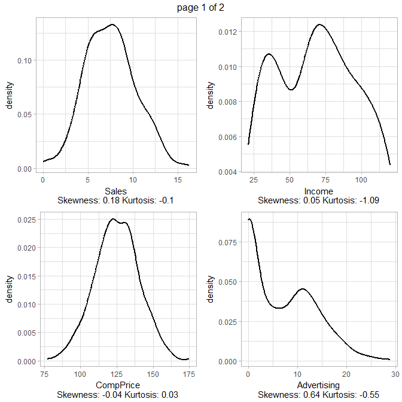

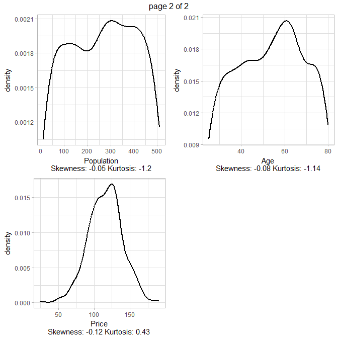

```r
# Note: Variable excluded (if unique value of variable which is less than or eaual to 10 [nlim=10])
ExpNumViz(Carseats,gp=NULL,nlim=10,Page=c(2,2),sample=8)
```

#### 1.3. Summary of categorical variables

- frequency for all categorical independent variables

```r
ExpCTable(Carseats,Target=NULL,margin=1,clim=10,nlim=NULL,round=2,bin=NULL,per=T)
```

| Variable | Valid | Frequency | Percent | CumPercent |
| --- | --- | --- | --- | --- |
| ShelveLoc | Bad | 96 | 24.00 | 24.00 |
| ShelveLoc | Good | 85 | 21.25 | 45.25 |
| ShelveLoc | Medium | 219 | 54.75 | 100.00 |
| ShelveLoc | TOTAL | 400 | NA | NA |
| Urban | No | 118 | 29.50 | 29.50 |
| Urban | Yes | 282 | 70.50 | 100.00 |
| Urban | TOTAL | 400 | NA | NA |
| US | No | 142 | 35.50 | 35.50 |
| US | Yes | 258 | 64.50 | 100.00 |
| US | TOTAL | 400 | NA | NA |

> *`NA` is Not Applicable*

#### 1.4. Distributions of categorical variables

- Bar plots for all categorical variables

```
## $`0`
```

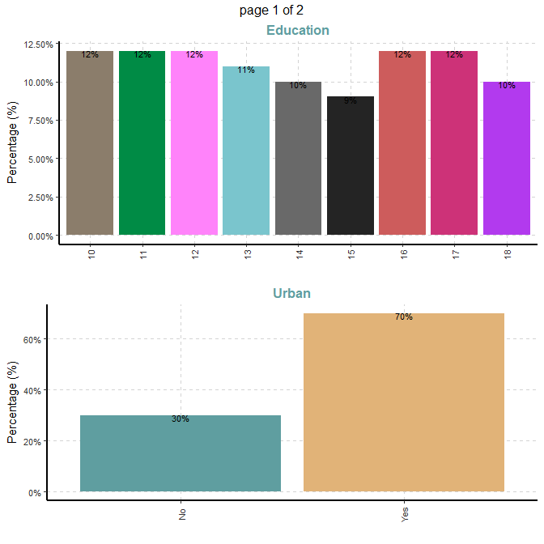

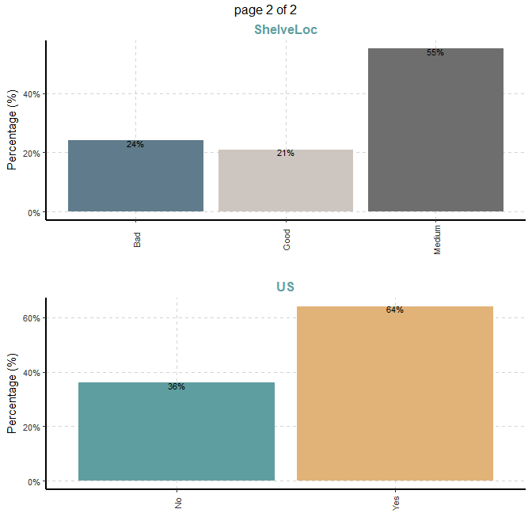

```r
ExpCatViz(Carseats,gp=NULL,fname=NULL,clim=10,margin=2,Page = c(2,1),sample=4)
```

### Example for case 2: Target variable is continuous

#### 2.1. Target variable

Summary of continuous dependent variable

1. Variable name - **Price**
2. Variable description - **Price company charges for car seats at each site**

```r
summary(Carseats[,"Price"])
```

```
##      Price
##  Min.   : 24.0
##  1st Qu.:100.0
##  Median :117.0
##  Mean   :115.8
##  3rd Qu.:131.0
##  Max.   :191.0
```

#### 2.2 Summary of numerical variables

Summary statistics when dependent variable is continuous **Price**.

```r
ExpNumStat(Carseats,by="A",gp="Price",Qnt=seq(0,1,0.1),MesofShape=1,Outlier=TRUE,round=2)
```

| Vname | Note | TN | nNeg | nZero | nPos | NegInf | PosInf | NA_Value | Per_of_Missing | sum | min | max | mean | median | SD | CV | IQR | 0% | 10% | 20% | 30% | 40% | 50% | 60% | 70% | 80% | 90% | 100% | LB.25% | … |
| --- | --- | --- | --- | --- | --- | --- | --- | --- | --- | --- | --- | --- | --- | --- | --- | --- | --- | --- | --- | --- | --- | --- | --- | --- | --- | --- | --- | --- | --- | --- |
| Advertising | Cor b/w Price | 400 | 0 | 144 | 256 | 0 | 0 | 0 | 0 | 2654.00 | 0 | 29.00 | 6.63 | 5.00 | 6.65 | 1.00 | 12.00 | 0 | 0.00 | 0.00 | 0.00 | 2.00 | 5.00 | 8.40 | 11.00 | 13.00 | 16.0 | 29.00 | -18.00 | … |
| Age | Cor b/w Price | 400 | 0 | 0 | 400 | 0 | 0 | 0 | 0 | 21329.00 | 25 | 80.00 | 53.32 | 54.50 | 16.20 | 0.30 | 26.25 | 25 | 30.00 | 36.00 | 43.00 | 48.60 | 54.50 | 60.00 | 64.00 | 70.00 | 76.0 | 80.00 | 0.38 | … |
| CompPrice | Cor b/w Price | 400 | 0 | 0 | 400 | 0 | 0 | 0 | 0 | 49990.00 | 77 | 175.00 | 124.97 | 125.00 | 15.33 | 0.12 | 20.00 | 77 | 106.00 | 112.80 | 117.00 | 121.00 | 125.00 | 130.00 | 133.00 | 137.20 | 145.0 | 175.00 | 85.00 | … |
| Education | Cor b/w Price | 400 | 0 | 0 | 400 | 0 | 0 | 0 | 0 | 5560.00 | 10 | 18.00 | 13.90 | 14.00 | 2.62 | 0.19 | 4.00 | 10 | 10.00 | 11.00 | 12.00 | 13.00 | 14.00 | 15.00 | 16.00 | 17.00 | 17.1 | 18.00 | 6.00 | … |
| Income | Cor b/w Price | 400 | 0 | 0 | 400 | 0 | 0 | 0 | 0 | 27463.00 | 21 | 120.00 | 68.66 | 69.00 | 27.99 | 0.41 | 48.25 | 21 | 30.00 | 39.00 | 48.00 | 62.00 | 69.00 | 77.00 | 84.60 | 96.20 | 107.0 | 120.00 | -29.62 | … |
| Population | Cor b/w Price | 400 | 0 | 0 | 400 | 0 | 0 | 0 | 0 | 105936.00 | 10 | 509.00 | 264.84 | 272.00 | 147.38 | 0.56 | 259.50 | 10 | 58.90 | 110.40 | 160.00 | 218.60 | 272.00 | 317.80 | 366.00 | 412.20 | 467.0 | 509.00 | -250.25 | … |
| Price | Cor b/w Price | 400 | 0 | 0 | 400 | 0 | 0 | 0 | 0 | 46318.00 | 24 | 191.00 | 115.80 | 117.00 | 23.68 | 0.20 | 31.00 | 24 | 87.00 | 96.80 | 104.00 | 110.00 | 117.00 | 122.00 | 128.30 | 134.00 | 146.0 | 191.00 | 53.50 | … |
| Sales | Cor b/w Price | 400 | 0 | 1 | 399 | 0 | 0 | 0 | 0 | 2998.53 | 0 | 16.27 | 7.50 | 7.49 | 2.82 | 0.38 | 3.93 | 0 | 4.12 | 5.07 | 5.87 | 6.61 | 7.49 | 8.08 | 8.82 | 9.76 | 11.3 | 16.27 | -0.50 | … |

> *If Target variable is continuous, summary statistics will add the correlation column (Correlation between Target variable vs all independet variables)*

#### 2.3 Distributions of numerical variables

Graphical representation of all numeric variables

- Scatter plot (Bivariate)

Scatter plot between all numeric variables and target variable **Price**. This plot help to examine how well a target variable is correlated with dependent variables.

Dependent variable is **Price** (continuous).

```
## $`0`
```

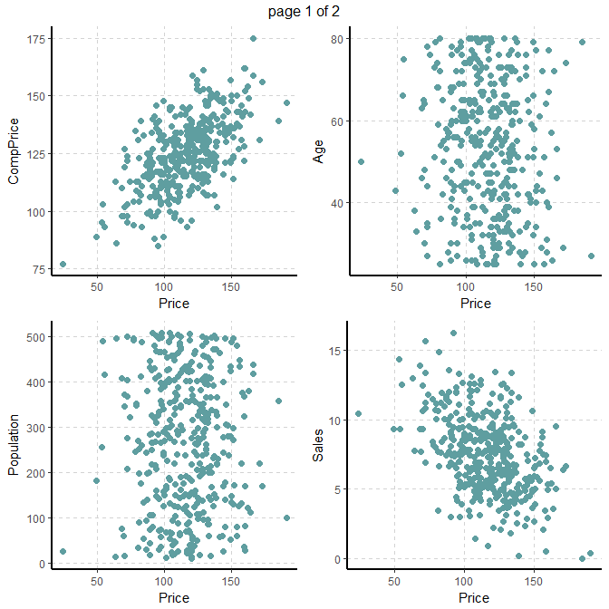

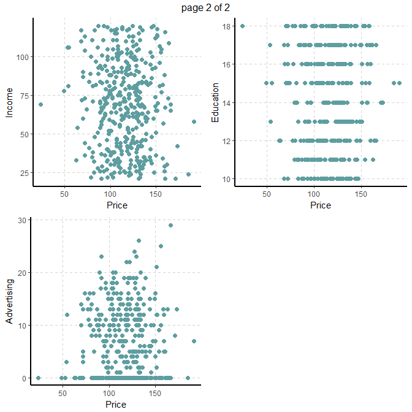

```r
#Note: sample=8 means randomly selected 8 scatter plots
#Note: nlim=4 means included numeric variable with unique value is more than 4
ExpNumViz(Carseats,gp="Price",nlim=4,fname=NULL,col=NULL,Page=c(2,2),sample=8)
```